# Analyse des opinions par règles sur des données de twitter

##### Author : Hugo Michel

## ----- Import libs -----

```python
#nltk.download('wordnet')
#nltk.download('universal_tagset')
#nltk.download('vader_lexicon')
```

```python
# --- import utils libs ---
import numpy as np
import pandas as pd
import re

# --- import ML libs ---
from sklearn.metrics import confusion_matrix
import seaborn as sns

# --- import nlp libs ---
import nltk
from nltk.tokenize import word_tokenize
from nltk.tokenize import TweetTokenizer
from nltk.tag import pos_tag
from nltk.corpus import wordnet as wn
from nltk.corpus.reader import sentiwordnet as swn
from nltk.tag import map_tag

from nltk.sentiment.vader import SentimentIntensityAnalyzer # Vader
```

## Implémentation d’un système d’analyse d’opinions

### 1/ Présentation du corpus de tweets

#### Importation du corpus de tweet

1. **polarity** = La polarité du tweet : Chaque tweet est accompagné d’un score pouvant être égal à 0 (négatif), 2 (neutre) ou 4 (positif).
2. **id** = L’identifiant du tweet (2087)
3. **date** = La date du tweet (Sat May 16 23 :58 :44 UTC 2009)
4. **query** = La requête associée (lyx). Si pas de requête la valeur est NO_ QUERY.
5. **author** = L’utilisateur qui a tweeté (robotickilldozr)
6. **content** = Le texte du tweet (Lyx is cool)

```python
tweets = pd.read_csv("data/testdata.manual.2009.06.14.csv", sep=",", names = ["polarity", "id", "date", "query", "author", "content"], header=None)
tweets
```

|  | polarity | id | date | query | author | content |
| --- | --- | --- | --- | --- | --- | --- |
| 0 | 4 | 3 | Mon May 11 03:17:40 UTC 2009 | kindle2 | tpryan | @stellargirl I loooooooovvvvvveee my Kindle2. ... |
| 1 | 4 | 4 | Mon May 11 03:18:03 UTC 2009 | kindle2 | vcu451 | Reading my kindle2... Love it... Lee childs i... |
| 2 | 4 | 5 | Mon May 11 03:18:54 UTC 2009 | kindle2 | chadfu | Ok, first assesment of the #kindle2 ...it fuck... |
| 3 | 4 | 6 | Mon May 11 03:19:04 UTC 2009 | kindle2 | SIX15 | @kenburbary You'll love your Kindle2. I've had... |
| 4 | 4 | 7 | Mon May 11 03:21:41 UTC 2009 | kindle2 | yamarama | @mikefish Fair enough. But i have the Kindle2... |
| ... | ... | ... | ... | ... | ... | ... |
| 493 | 2 | 14072 | Sun Jun 14 04:31:43 UTC 2009 | latex | proggit | Ask Programming: LaTeX or InDesign?: submitted... |
| 494 | 0 | 14073 | Sun Jun 14 04:32:17 UTC 2009 | latex | sam33r | On that note, I hate Word. I hate Pages. I hat... |
| 495 | 4 | 14074 | Sun Jun 14 04:36:34 UTC 2009 | latex | iamtheonlyjosie | Ahhh... back in a *real* text editing environm... |
| 496 | 0 | 14075 | Sun Jun 14 21:36:07 UTC 2009 | iran | plutopup7 | Trouble in Iran, I see. Hmm. Iran. Iran so far... |
| 497 | 0 | 14076 | Sun Jun 14 21:36:17 UTC 2009 | iran | captain_pete | Reading the tweets coming out of Iran... The w... |

498 rows × 6 columns

### Lecture du dictionnaire `DicoSlang`

Corriger les abréviations et les spécificités langagières des tweets à l’aide du dictionnaire DicoSlang

```python
dico_slang = pd.read_csv("data/SlangLookupTable.txt", sep="\t", names = ["original", "new"], header=None, encoding = "latin1")
dico_slang
```

|  | original | new |
| --- | --- | --- |
| 0 | 121 | one to one |
| 1 | a/s/l | age, sex, location |
| 2 | adn | any day now |
| 3 | afaik | as far as I know |
| 4 | afk | away from keyboard |
| ... | ... | ... |
| 85 | wibni | wouldn't it be nice if |
| 86 | wtf | what the fuck |
| 87 | wtg | way to go |
| 88 | wtgp | want to go private |
| 89 | ym | young man |

90 rows × 2 columns

### 2/ Prétraitements du corpus

Écrire une fonction permettant pour chaque tweet de :

- Récupérer le texte associé
- Le segmenter en tokens
- Supprimer les urls
- Nettoyer les caractères inhérents à la structure d’un tweet (hashtags !)
- Corriger les abréviations et les spécificités langagières des tweets à l’aide du dictionnaire **DicoSlang** (fichier `SlangLookupTable.txt`)

```python
def preprocessing_tweet(text_tweet, dico_slang):

    # tokenization du tweet avec TweetTokenizer (garde les émoticones, retire les @[username])
    tk = nltk.TweetTokenizer()
    text_tweet_tokenized = tk.tokenize(text_tweet)
    text_tweet_cleaned = list()

    original_list = dico_slang["original"].to_list()
    new_list = dico_slang["new"].to_list()

    # remove inherent tweet special characters like #hashtag
    for elm in text_tweet_tokenized:
        if elm.startswith('http'):
            pass

        elif elm.startswith('@'):
            pass

        elif elm.startswith("#"):
            elm = elm.split("#")[1]
            text_tweet_cleaned.append(elm)

        else:
            text_tweet_cleaned.append(elm)

        # Correction des abréviations et des spécificités langagières des tweets
        for i in range (len(original_list)):
            if original_list[i] == elm:
                new = new_list[i]
                list_word = word_tokenize(new)
                for word in list_word:
                    text_tweet_cleaned.append(word)

            if original_list[i] == elm:
                text_tweet_cleaned.remove(elm)

        # Remove empty string
        text_tweet_cleaned = [e for e in text_tweet_cleaned if e]

    return text_tweet_cleaned
```

#### Test de la fonction `preprocessing_tweet`

```python
print("Original tweet test\n")
text_tweet = "121 @stellargirl #looser adn [link] [1 comment] @author #looser This is ! a text with! a URL https://www.java2blog.com/ to remove + :) ok =) ='( / #looser [link] [1 comment] @author #looser."
print(text_tweet)
print("\n-------------------\n")

print("Tweet test cleaned\n")
print(preprocessing_tweet(text_tweet, dico_slang))
```

```
Original tweet test

121 @stellargirl #looser adn [link] [1 comment] @author #looser This is ! a text with! a URL https://www.java2blog.com/ to remove + :) ok =) ='( / #looser [link] [1 comment] @author #looser.

-------------------

Tweet test cleaned

['one', 'to', 'one', 'looser', 'any', 'day', 'now', '[', 'link', ']', '[', '1', 'comment', ']', 'looser', 'This', 'is', '!', 'a', 'text', 'with', '!', 'a', 'URL', 'to', 'remove', '+', ':)', 'ok', '=)', "='(", '/', 'looser', '[', 'link', ']', '[', '1', 'comment', ']', 'looser', '.']
```

#### Test de la fonction `preprocessing_tweet`

#### Pré-processing des tweets de notre dataset

```python
l_token = list()
for i in range(tweets.shape[0]):
    l_token.append(preprocessing_tweet(tweets.iloc[i,5], dico_slang))

tweets = tweets.join(pd.DataFrame({"tweet_cleaned":l_token}))
tweets
```

|  | polarity | id | date | query | author | content | tweet_cleaned |
| --- | --- | --- | --- | --- | --- | --- | --- |
| 0 | 4 | 3 | Mon May 11 03:17:40 UTC 2009 | kindle2 | tpryan | @stellargirl I loooooooovvvvvveee my Kindle2. ... | [I, loooooooovvvvvveee, my, Kindle, 2, ., Not,... |
| 1 | 4 | 4 | Mon May 11 03:18:03 UTC 2009 | kindle2 | vcu451 | Reading my kindle2... Love it... Lee childs i... | [Reading, my, kindle, 2, ..., Love, it, ..., L... |
| 2 | 4 | 5 | Mon May 11 03:18:54 UTC 2009 | kindle2 | chadfu | Ok, first assesment of the #kindle2 ...it fuck... | [Ok, ,, first, assesment, of, the, kindle2, ..... |
| 3 | 4 | 6 | Mon May 11 03:19:04 UTC 2009 | kindle2 | SIX15 | @kenburbary You'll love your Kindle2. I've had... | [You'll, love, your, Kindle, 2, ., I've, had, ... |
| 4 | 4 | 7 | Mon May 11 03:21:41 UTC 2009 | kindle2 | yamarama | @mikefish Fair enough. But i have the Kindle2... | [Fair, enough, ., But, i, have, the, Kindle, 2... |
| ... | ... | ... | ... | ... | ... | ... | ... |
| 493 | 2 | 14072 | Sun Jun 14 04:31:43 UTC 2009 | latex | proggit | Ask Programming: LaTeX or InDesign?: submitted... | [Ask, Programming, :, LaTeX, or, InDesign, ?, ... |
| 494 | 0 | 14073 | Sun Jun 14 04:32:17 UTC 2009 | latex | sam33r | On that note, I hate Word. I hate Pages. I hat... | [On, that, note, ,, I, hate, Word, ., I, hate,... |
| 495 | 4 | 14074 | Sun Jun 14 04:36:34 UTC 2009 | latex | iamtheonlyjosie | Ahhh... back in a *real* text editing environm... | [Ahhh, ..., back, in, a, *, real, *, text, edi... |
| 496 | 0 | 14075 | Sun Jun 14 21:36:07 UTC 2009 | iran | plutopup7 | Trouble in Iran, I see. Hmm. Iran. Iran so far... | [Trouble, in, Iran, ,, I, see, ., Hmm, ., Iran... |
| 497 | 0 | 14076 | Sun Jun 14 21:36:17 UTC 2009 | iran | captain_pete | Reading the tweets coming out of Iran... The w... | [Reading, the, tweets, coming, out, of, Iran, ... |

498 rows × 7 columns

### 3/ Étiquetage grammatical

#### Test de la fonction `pos_tagger`

```python
def pos_tagger(tweet_tokenized):
    tweet_pos_tag = nltk.pos_tag(tweet_tokenized)
    pos = [(word, map_tag('en-ptb', 'universal', tag)) for word, tag in tweet_pos_tag]
    return pos

tweet_bis = tweets["tweet_cleaned"][0]
pos_tagger(tweet_bis)
```

```
[('I', 'PRON'),
 ('loooooooovvvvvveee', 'VERB'),
 ('my', 'PRON'),
 ('Kindle', 'NOUN'),
 ('2', 'NUM'),
 ('.', '.'),
 ('Not', 'ADV'),
 ('that', 'ADP'),
 ('the', 'DET'),
 ('DX', 'NOUN'),
 ('is', 'VERB'),
 ('cool', 'ADJ'),
 (',', '.'),
 ('but', 'CONJ'),
 ('the', 'DET'),
 ('2', 'NUM'),
 ('is', 'VERB'),
 ('fantastic', 'ADJ'),
 ('in', 'ADP'),
 ('its', 'PRON'),
 ('own', 'ADJ'),
 ('right', 'NOUN'),
 ('.', '.')]
```

#### Pos tagging des tweets de notre dataset

```python
l_tag = list()
for i in range(tweets.shape[0]):
    tagging = pos_tagger(tweets.iloc[i,6])
    l_tag.append(tagging)

tweets = tweets.join(pd.DataFrame({"tweet_pos_tag":l_tag}))
tweets
```

|  | polarity | id | date | query | author | content | tweet_cleaned | tweet_pos_tag |
| --- | --- | --- | --- | --- | --- | --- | --- | --- |
| 0 | 4 | 3 | Mon May 11 03:17:40 UTC 2009 | kindle2 | tpryan | @stellargirl I loooooooovvvvvveee my Kindle2. ... | [I, loooooooovvvvvveee, my, Kindle, 2, ., Not,... | [(I, PRON), (loooooooovvvvvveee, VERB), (my, P... |
| 1 | 4 | 4 | Mon May 11 03:18:03 UTC 2009 | kindle2 | vcu451 | Reading my kindle2... Love it... Lee childs i... | [Reading, my, kindle, 2, ..., Love, it, ..., L... | [(Reading, VERB), (my, PRON), (kindle, NOUN), ... |
| 2 | 4 | 5 | Mon May 11 03:18:54 UTC 2009 | kindle2 | chadfu | Ok, first assesment of the #kindle2 ...it fuck... | [Ok, ,, first, assesment, of, the, kindle2, ..... | [(Ok, NOUN), (,, .), (first, ADJ), (assesment,... |
| 3 | 4 | 6 | Mon May 11 03:19:04 UTC 2009 | kindle2 | SIX15 | @kenburbary You'll love your Kindle2. I've had... | [You'll, love, your, Kindle, 2, ., I've, had, ... | [(You'll, NOUN), (love, VERB), (your, PRON), (... |
| 4 | 4 | 7 | Mon May 11 03:21:41 UTC 2009 | kindle2 | yamarama | @mikefish Fair enough. But i have the Kindle2... | [Fair, enough, ., But, i, have, the, Kindle, 2... | [(Fair, NOUN), (enough, ADV), (., .), (But, CO... |
| ... | ... | ... | ... | ... | ... | ... | ... | ... |
| 493 | 2 | 14072 | Sun Jun 14 04:31:43 UTC 2009 | latex | proggit | Ask Programming: LaTeX or InDesign?: submitted... | [Ask, Programming, :, LaTeX, or, InDesign, ?, ... | [(Ask, NOUN), (Programming, NOUN), (:, .), (La... |
| 494 | 0 | 14073 | Sun Jun 14 04:32:17 UTC 2009 | latex | sam33r | On that note, I hate Word. I hate Pages. I hat... | [On, that, note, ,, I, hate, Word, ., I, hate,... | [(On, ADP), (that, DET), (note, NOUN), (,, .),... |
| 495 | 4 | 14074 | Sun Jun 14 04:36:34 UTC 2009 | latex | iamtheonlyjosie | Ahhh... back in a *real* text editing environm... | [Ahhh, ..., back, in, a, *, real, *, text, edi... | [(Ahhh, NOUN), (..., .), (back, ADV), (in, ADP... |
| 496 | 0 | 14075 | Sun Jun 14 21:36:07 UTC 2009 | iran | plutopup7 | Trouble in Iran, I see. Hmm. Iran. Iran so far... | [Trouble, in, Iran, ,, I, see, ., Hmm, ., Iran... | [(Trouble, NOUN), (in, ADP), (Iran, NOUN), (,,... |
| 497 | 0 | 14076 | Sun Jun 14 21:36:17 UTC 2009 | iran | captain_pete | Reading the tweets coming out of Iran... The w... | [Reading, the, tweets, coming, out, of, Iran, ... | [(Reading, VERB), (the, DET), (tweets, NOUN), ... |

498 rows × 8 columns

##### Vous pourrez ensuite, à l’aide de cette fonction, compter le nombre de mots étiquetés verbes dans le corpus

On compte le nombre de fois que l'on obtient le **tag** `VERB` dans le corpus de tweet

```python
list_pos_tag_ = tweets["tweet_pos_tag"].to_list()

verb_counter = 0

# On parcourt la liste des tweets
for i in range(len(list_pos_tag_)):
    for j in range(len(list_pos_tag_[i])):
        # On ajoute +1 si le tag en question est "VERB" (i.e le mot est un verbe)
        if list_pos_tag_[i][j][1] == 'VERB':
            verb_counter = verb_counter + 1

print("Il y a " + str(verb_counter) + " mot étiquetés 'VERB' dans le corpus de tweet")
```

```
Il y a 1087 mot étiquetés 'VERB' dans le corpus de tweet
```

### 4/ Algorithme de détection : utilisation du dictionnaire Sentiwordnet

- Calcul pour chaque tweet de la somme des scores positifs et négatifs des synsets du tweet (1er synset),
- Comparaison de la somme des scores positifs et des scores négatifs de chaque tweet pour décider de la classe à associer au tweet.

#### Note : Pour la suite du TP le calcul des scores positifs et négatifs des synsets du tweet se basera automatique sur le 1er synset du mot en question

#### Compute sentiment score for a tweet

```python
def compute_sentiment_score(post_tag_tweet):

    # ---- Initialisation ----
    accepted_tag = ["NOUN", "ADV", "VERB", "ADJ"]

    dicoSentiWordnetFile = 'data/SentiWordNet_3.0.0_20130122.txt'
    swn_dict = swn.SentiWordNetCorpusReader('', [dicoSentiWordnetFile])

    list_positive_score = list()
    list_negative_score = list()

    # Parcourt de la liste de tag
    for tag in post_tag_tweet:
        # Recherche du mot en question dans le dico (on prend le premeir synset de ce dernier)
        senti_dict = list(swn_dict.senti_synsets(tag[0]))
        # On vérifie que le mot en question contient bien un tag accepté et on vérifie que le mot est bien contenu dans le dico
        if tag[1] in accepted_tag and len(senti_dict) > 0:
            # On cherche le premier synset qui correspond au mot en question
            for idx, elm in enumerate(senti_dict):
                word = str(elm).split(".")[0].split("<")[1]
                # Si le mot correspond bien au premier synset on calcul les scores
                if word == tag[0].lower():
                    list_positive_score.append(senti_dict[idx].pos_score())
                    list_negative_score.append(senti_dict[idx].neg_score())
                    break

    # On somme les scores des différents mots composant le tweet en question
    score_positive = sum(list_positive_score)
    score_negative = sum(list_negative_score)

    # On défnit la classe majoritaire
    if score_positive > score_negative:
        classe = "positif"
    if score_positive < score_negative:
        classe = "negatif"
    if score_positive == score_negative:
        classe = "neutre"

    return [score_positive, score_negative, classe]
```

### On calcul le score de chaque tweet

```python
l_sentiment_scores = list()
for i in range(tweets.shape[0]):
    print(i)
    score = compute_sentiment_score(tweets.iloc[i,7])
    l_sentiment_scores.append(score)

tweets = tweets.join(pd.DataFrame({"sentiment_scores":l_sentiment_scores}))
tweets
```

[output not shown]

[output cut: 443 more lines]

[output not shown]

|  | polarity | id | date | query | author | content | tweet_cleaned | tweet_pos_tag | sentiment_scores |
| --- | --- | --- | --- | --- | --- | --- | --- | --- | --- |
| 0 | 4 | 3 | Mon May 11 03:17:40 UTC 2009 | kindle2 | tpryan | @stellargirl I loooooooovvvvvveee my Kindle2. ... | [I, loooooooovvvvvveee, my, Kindle, 2, ., Not,... | [(I, PRON), (loooooooovvvvvveee, VERB), (my, P... | [1.0, 1.0, neutre] |
| 1 | 4 | 4 | Mon May 11 03:18:03 UTC 2009 | kindle2 | vcu451 | Reading my kindle2... Love it... Lee childs i... | [Reading, my, kindle, 2, ..., Love, it, ..., L... | [(Reading, VERB), (my, PRON), (kindle, NOUN), ... | [1.375, 0.0, positif] |
| 2 | 4 | 5 | Mon May 11 03:18:54 UTC 2009 | kindle2 | chadfu | Ok, first assesment of the #kindle2 ...it fuck... | [Ok, ,, first, assesment, of, the, kindle2, ..... | [(Ok, NOUN), (,, .), (first, ADJ), (assesment,... | [0.125, 0.0, positif] |
| 3 | 4 | 6 | Mon May 11 03:19:04 UTC 2009 | kindle2 | SIX15 | @kenburbary You'll love your Kindle2. I've had... | [You'll, love, your, Kindle, 2, ., I've, had, ... | [(You'll, NOUN), (love, VERB), (your, PRON), (... | [1.25, 0.875, positif] |
| 4 | 4 | 7 | Mon May 11 03:21:41 UTC 2009 | kindle2 | yamarama | @mikefish Fair enough. But i have the Kindle2... | [Fair, enough, ., But, i, have, the, Kindle, 2... | [(Fair, NOUN), (enough, ADV), (., .), (But, CO... | [0.25, 0.0, positif] |
| ... | ... | ... | ... | ... | ... | ... | ... | ... | ... |
| 493 | 2 | 14072 | Sun Jun 14 04:31:43 UTC 2009 | latex | proggit | Ask Programming: LaTeX or InDesign?: submitted... | [Ask, Programming, :, LaTeX, or, InDesign, ?, ... | [(Ask, NOUN), (Programming, NOUN), (:, .), (La... | [0.0, 0.0, neutre] |
| 494 | 0 | 14073 | Sun Jun 14 04:32:17 UTC 2009 | latex | sam33r | On that note, I hate Word. I hate Pages. I hat... | [On, that, note, ,, I, hate, Word, ., I, hate,... | [(On, ADP), (that, DET), (note, NOUN), (,, .),... | [0.5, 1.5, negatif] |
| 495 | 4 | 14074 | Sun Jun 14 04:36:34 UTC 2009 | latex | iamtheonlyjosie | Ahhh... back in a *real* text editing environm... | [Ahhh, ..., back, in, a, *, real, *, text, edi... | [(Ahhh, NOUN), (..., .), (back, ADV), (in, ADP... | [0.0, 0.0, neutre] |
| 496 | 0 | 14075 | Sun Jun 14 21:36:07 UTC 2009 | iran | plutopup7 | Trouble in Iran, I see. Hmm. Iran. Iran so far... | [Trouble, in, Iran, ,, I, see, ., Hmm, ., Iran... | [(Trouble, NOUN), (in, ADP), (Iran, NOUN), (,,... | [0.0, 0.25, negatif] |
| 497 | 0 | 14076 | Sun Jun 14 21:36:17 UTC 2009 | iran | captain_pete | Reading the tweets coming out of Iran... The w... | [Reading, the, tweets, coming, out, of, Iran, ... | [(Reading, VERB), (the, DET), (tweets, NOUN), ... | [0.125, 1.25, negatif] |

498 rows × 9 columns

```python
tweets
```

|  | polarity | id | date | query | author | content | tweet_cleaned | tweet_pos_tag | sentiment_scores |
| --- | --- | --- | --- | --- | --- | --- | --- | --- | --- |
| 0 | 4 | 3 | Mon May 11 03:17:40 UTC 2009 | kindle2 | tpryan | @stellargirl I loooooooovvvvvveee my Kindle2. ... | [I, loooooooovvvvvveee, my, Kindle, 2, ., Not,... | [(I, PRON), (loooooooovvvvvveee, VERB), (my, P... | [1.0, 1.0, neutre] |
| 1 | 4 | 4 | Mon May 11 03:18:03 UTC 2009 | kindle2 | vcu451 | Reading my kindle2... Love it... Lee childs i... | [Reading, my, kindle, 2, ..., Love, it, ..., L... | [(Reading, VERB), (my, PRON), (kindle, NOUN), ... | [1.375, 0.0, positif] |
| 2 | 4 | 5 | Mon May 11 03:18:54 UTC 2009 | kindle2 | chadfu | Ok, first assesment of the #kindle2 ...it fuck... | [Ok, ,, first, assesment, of, the, kindle2, ..... | [(Ok, NOUN), (,, .), (first, ADJ), (assesment,... | [0.125, 0.0, positif] |
| 3 | 4 | 6 | Mon May 11 03:19:04 UTC 2009 | kindle2 | SIX15 | @kenburbary You'll love your Kindle2. I've had... | [You'll, love, your, Kindle, 2, ., I've, had, ... | [(You'll, NOUN), (love, VERB), (your, PRON), (... | [1.25, 0.875, positif] |
| 4 | 4 | 7 | Mon May 11 03:21:41 UTC 2009 | kindle2 | yamarama | @mikefish Fair enough. But i have the Kindle2... | [Fair, enough, ., But, i, have, the, Kindle, 2... | [(Fair, NOUN), (enough, ADV), (., .), (But, CO... | [0.25, 0.0, positif] |
| ... | ... | ... | ... | ... | ... | ... | ... | ... | ... |
| 493 | 2 | 14072 | Sun Jun 14 04:31:43 UTC 2009 | latex | proggit | Ask Programming: LaTeX or InDesign?: submitted... | [Ask, Programming, :, LaTeX, or, InDesign, ?, ... | [(Ask, NOUN), (Programming, NOUN), (:, .), (La... | [0.0, 0.0, neutre] |
| 494 | 0 | 14073 | Sun Jun 14 04:32:17 UTC 2009 | latex | sam33r | On that note, I hate Word. I hate Pages. I hat... | [On, that, note, ,, I, hate, Word, ., I, hate,... | [(On, ADP), (that, DET), (note, NOUN), (,, .),... | [0.5, 1.5, negatif] |
| 495 | 4 | 14074 | Sun Jun 14 04:36:34 UTC 2009 | latex | iamtheonlyjosie | Ahhh... back in a *real* text editing environm... | [Ahhh, ..., back, in, a, *, real, *, text, edi... | [(Ahhh, NOUN), (..., .), (back, ADV), (in, ADP... | [0.0, 0.0, neutre] |
| 496 | 0 | 14075 | Sun Jun 14 21:36:07 UTC 2009 | iran | plutopup7 | Trouble in Iran, I see. Hmm. Iran. Iran so far... | [Trouble, in, Iran, ,, I, see, ., Hmm, ., Iran... | [(Trouble, NOUN), (in, ADP), (Iran, NOUN), (,,... | [0.0, 0.25, negatif] |
| 497 | 0 | 14076 | Sun Jun 14 21:36:17 UTC 2009 | iran | captain_pete | Reading the tweets coming out of Iran... The w... | [Reading, the, tweets, coming, out, of, Iran, ... | [(Reading, VERB), (the, DET), (tweets, NOUN), ... | [0.125, 1.25, negatif] |

498 rows × 9 columns

##### Vous utiliserez cet algorithme pour analyser les opinions des tweets du corpus, et préciserez nombre de tweets correctement analysés pour chaque catégorie (positif, neutre, négatif).

```python
df_sentiments = pd.DataFrame()

list_our_polarity_classe = list()
list_true_polarity_classe = list()

for i in range(tweets.shape[0]):

    classe = tweets["sentiment_scores"][i][2]
    list_our_polarity_classe.append(classe)

    if tweets["polarity"][i] == 4:
        list_true_polarity_classe.append("positif")

    if tweets["polarity"][i] == 2:
        list_true_polarity_classe.append("neutre")

    if tweets["polarity"][i] == 0:
        list_true_polarity_classe.append("negatif")

df_sentiments["true_polarity"] = list_true_polarity_classe
df_sentiments["our_polarity"] = list_our_polarity_classe

df_sentiments
```

|  | true_polarity | our_polarity |
| --- | --- | --- |
| 0 | positif | neutre |
| 1 | positif | positif |
| 2 | positif | positif |
| 3 | positif | positif |
| 4 | positif | positif |
| ... | ... | ... |
| 493 | neutre | neutre |
| 494 | negatif | negatif |
| 495 | positif | neutre |
| 496 | negatif | negatif |
| 497 | negatif | negatif |

498 rows × 2 columns

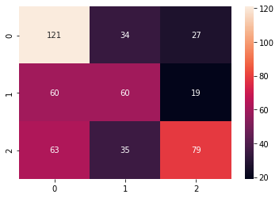

```python
conf_matrix = confusion_matrix(df_sentiments["true_polarity"], df_sentiments["our_polarity"], labels=['positif', 'neutre', 'negatif'])

sns.heatmap(conf_matrix, annot=True, fmt='d')
```

### 5/ Algorithme de détection : gestion de la négation et des modifieurs

Pour chaque mot, l’algorithme doit effectuer les opérations suivantes :

- multiplie par 2 le score négatif et le score positif associés au mot si le mot précédent est un modifieur
- utilise uniquement le score négatif du mot pour le score positif global du tweet et le score positif du mot pour le score négatif global du tweet si le mot précédent est une négation.

#### Lecture de la liste contenant les négations `NegatingWordList.txt`

```python
neg_word_df = pd.read_csv("data/NegatingWordList.txt", header = None)
neg_word_df
```

|  | 0 |
| --- | --- |
| 0 | aren't |
| 1 | arent |
| 2 | can't |
| 3 | cannot |
| 4 | cant |
| 5 | don't |
| 6 | dont |
| 7 | isn't |
| 8 | isnt |
| 9 | never |
| 10 | not |
| 11 | won't |
| 12 | wont |
| 13 | wouldn't |
| 14 | wouldnt |

#### Lecture de la liste contenant les modieurs (booster)

```python
booster_word_df = pd.read_csv("data/BoosterWordList.txt", sep='\t', header = None)
booster_word_df
```

|  | 0 | 1 |
| --- | --- | --- |
| 0 | absolutely | 1 |
| 1 | definitely | 1 |
| 2 | extremely | 2 |
| 3 | fuckin | 2 |
| 4 | fucking | 2 |
| 5 | hugely | 2 |
| 6 | incredibly | 2 |
| 7 | just | -1 |
| 8 | overwhelmingly | 2 |
| 9 | so | 0 |
| 10 | some | -1 |
| 11 | sum | -1 |
| 12 | very | 1 |

### Compute sentiment score

Dans un premier temps, l'idée est re-implémenter la fonction qui calcul le score de sentiment d'un tweet en se basant sur les 2 règles suivantes :

- multiplie par 2 le score négatif et le score positif associés au mot si le mot précédent est un modifieur
- utilise uniquement le score négatif du mot pour le score positif global du tweet et le score positif du mot pour le score négatif global du tweet si le mot précédent est une négation.

> Exemple : I don't like cat `don't` est une négation et le score du mot suivant `like`sont {score_pos : 0.125, score_neg : 0.0} alors le score positif global de la phrase est de : 0.0 et le score négatif global de la phrase devient : 0.125

On appellera cette fonction `compute_sentiment_score_1`

Dans un second temps, l'idée est de reprendre les règles que l'on a implémenté précédemment pour la première version du calcul du score du sentiment (section 3.4 : Algorithme de détection : utilisation du dictionnaire Sentiwordnet) d'un tweet et de les complexifier en ajoutant les règles de la section (section 3.5 : Algorithme de détection : gestion de la négation et des modifieurs)

Etant donné que l'on garde les règles que l'on à implémenté précédemment, on se concentre ici uniquement sur les mots dont le tag est **["NOUN", "ADV", "VERB", "ADJ"]**.

On appellera cette fonction `compute_sentiment_score_2`

L'enjeu sera alors de comparer ces 2 différentes approches :

- **Approche n°1 :** Règles spécifiées de la section 3.5 de l'énoncé
- **Approche n°2 :** Combinaisons des règles spécifiées de la section 3.4 et 3.5 de l'énoncé (Prise en compte uniquement des tags **["NOUN", "ADV", "VERB", "ADJ"]**

### Approche n°1

```python
def compute_sentiment_score_1(post_tag_tweet):

    # ---- Initialisation ----
    dicoSentiWordnetFile = 'data/SentiWordNet_3.0.0_20130122.txt'
    swn_dict = swn.SentiWordNetCorpusReader('', [dicoSentiWordnetFile])

    booster_word_df = pd.read_csv("data/BoosterWordList.txt", sep='\t', header = None)
    booster_word_list = booster_word_df[0].tolist()

    neg_word_df = pd.read_csv("data/NegatingWordList.txt", header = None)
    neg_word_list = neg_word_df[0].tolist()

    list_positive_score = list()
    list_negative_score = list()

    list_positive_score_global = list()
    list_negative_score_global = list()

    # Initialisation du score : On calcule le score du premier élément de la liste
    senti_dict = list(swn_dict.senti_synsets(post_tag_tweet[0][0]))
    if len(senti_dict) > 0:
        for idx, elm in enumerate(senti_dict):
                word = str(elm).split(".")[0].split("<")[1]
                if word == post_tag_tweet[0][0].lower():
                    list_positive_score.append(senti_dict[idx].pos_score())
                    list_negative_score.append(senti_dict[idx].neg_score())
                    break

    # Parcourt de la liste de tag
    for i in range (1, len(post_tag_tweet)):
        senti_dict = list(swn_dict.senti_synsets(post_tag_tweet[i][0]))
        if len(senti_dict) > 0:
            for idx, elm in enumerate(senti_dict):
                word = str(elm).split(".")[0].split("<")[1]
                if word == post_tag_tweet[i][0].lower():

                    # Si le mot précédent du mot courant est une négation
                    if post_tag_tweet[i-1][0].lower() in neg_word_list:
                        list_positive_score_global.append(senti_dict[idx].pos_score())
                        list_negative_score_global.append(senti_dict[idx].neg_score())
                        break

                    # Si le mot précédent du mot courant est un booster on multiplie les scores par 2
                    elif post_tag_tweet[i-1][0].lower() in booster_word_list:
                        list_positive_score.append(senti_dict[idx].pos_score() * 2)
                        list_negative_score.append(senti_dict[idx].neg_score() * 2)
                        break

                    else:
                        list_positive_score.append(senti_dict[idx].pos_score())
                        list_negative_score.append(senti_dict[idx].neg_score())
                        break

    # Si le tweet contient une négation
    # alors le score positif du mot courant devient le score positif global du tweet
    # alors le score négatif du mot courant devient le score  négatif global du tweet
    # Sinon On somme les scores des différents mots composant le tweet en question
    if len(list_positive_score_global) > 0:
        score_positive = list_negative_score_global[0]
        score_negative = list_positive_score_global[0]
    else:
        score_positive = sum(list_positive_score)
        score_negative = sum(list_negative_score)


    # On défnit la classe majoritaire
    if score_positive > score_negative:
        classe = "positif"
    if score_positive < score_negative:
        classe = "negatif"
    if score_positive == score_negative:
        classe = "neutre"

    return [score_positive, score_negative, classe]
```

#### Calcul des scores de sentiment pour chaque tweet

```python
l_sentiment_scores_1 = list()
for i in range(tweets.shape[0]):
    print(i)
    score = compute_sentiment_score_1(tweets.iloc[i,7])
    l_sentiment_scores_1.append(score)

tweets = tweets.join(pd.DataFrame({"sentiment_scores_1":l_sentiment_scores_1}))
tweets
```

[output not shown]

[output cut: 443 more lines]

[output not shown]

|  | polarity | id | date | query | author | content | tweet_cleaned | tweet_pos_tag | sentiment_scores | sentiment_scores_1 |
| --- | --- | --- | --- | --- | --- | --- | --- | --- | --- | --- |
| 0 | 4 | 3 | Mon May 11 03:17:40 UTC 2009 | kindle2 | tpryan | @stellargirl I loooooooovvvvvveee my Kindle2. ... | [I, loooooooovvvvvveee, my, Kindle, 2, ., Not,... | [(I, PRON), (loooooooovvvvvveee, VERB), (my, P... | [1.0, 1.0, neutre] | [1.0, 1.0, neutre] |
| 1 | 4 | 4 | Mon May 11 03:18:03 UTC 2009 | kindle2 | vcu451 | Reading my kindle2... Love it... Lee childs i... | [Reading, my, kindle, 2, ..., Love, it, ..., L... | [(Reading, VERB), (my, PRON), (kindle, NOUN), ... | [1.375, 0.0, positif] | [1.375, 0.0, positif] |
| 2 | 4 | 5 | Mon May 11 03:18:54 UTC 2009 | kindle2 | chadfu | Ok, first assesment of the #kindle2 ...it fuck... | [Ok, ,, first, assesment, of, the, kindle2, ..... | [(Ok, NOUN), (,, .), (first, ADJ), (assesment,... | [0.125, 0.0, positif] | [0.125, 0.0, positif] |
| 3 | 4 | 6 | Mon May 11 03:19:04 UTC 2009 | kindle2 | SIX15 | @kenburbary You'll love your Kindle2. I've had... | [You'll, love, your, Kindle, 2, ., I've, had, ... | [(You'll, NOUN), (love, VERB), (your, PRON), (... | [1.25, 0.875, positif] | [1.25, 1.125, positif] |
| 4 | 4 | 7 | Mon May 11 03:21:41 UTC 2009 | kindle2 | yamarama | @mikefish Fair enough. But i have the Kindle2... | [Fair, enough, ., But, i, have, the, Kindle, 2... | [(Fair, NOUN), (enough, ADV), (., .), (But, CO... | [0.25, 0.0, positif] | [0.25, 0.0, positif] |
| ... | ... | ... | ... | ... | ... | ... | ... | ... | ... | ... |
| 493 | 2 | 14072 | Sun Jun 14 04:31:43 UTC 2009 | latex | proggit | Ask Programming: LaTeX or InDesign?: submitted... | [Ask, Programming, :, LaTeX, or, InDesign, ?, ... | [(Ask, NOUN), (Programming, NOUN), (:, .), (La... | [0.0, 0.0, neutre] | [0.0, 0.0, neutre] |
| 494 | 0 | 14073 | Sun Jun 14 04:32:17 UTC 2009 | latex | sam33r | On that note, I hate Word. I hate Pages. I hat... | [On, that, note, ,, I, hate, Word, ., I, hate,... | [(On, ADP), (that, DET), (note, NOUN), (,, .),... | [0.5, 1.5, negatif] | [0.5, 1.5, negatif] |
| 495 | 4 | 14074 | Sun Jun 14 04:36:34 UTC 2009 | latex | iamtheonlyjosie | Ahhh... back in a *real* text editing environm... | [Ahhh, ..., back, in, a, *, real, *, text, edi... | [(Ahhh, NOUN), (..., .), (back, ADV), (in, ADP... | [0.0, 0.0, neutre] | [0.0, 0.0, neutre] |
| 496 | 0 | 14075 | Sun Jun 14 21:36:07 UTC 2009 | iran | plutopup7 | Trouble in Iran, I see. Hmm. Iran. Iran so far... | [Trouble, in, Iran, ,, I, see, ., Hmm, ., Iran... | [(Trouble, NOUN), (in, ADP), (Iran, NOUN), (,,... | [0.0, 0.25, negatif] | [0.0, 0.25, negatif] |
| 497 | 0 | 14076 | Sun Jun 14 21:36:17 UTC 2009 | iran | captain_pete | Reading the tweets coming out of Iran... The w... | [Reading, the, tweets, coming, out, of, Iran, ... | [(Reading, VERB), (the, DET), (tweets, NOUN), ... | [0.125, 1.25, negatif] | [0.25, 2.0, negatif] |

498 rows × 10 columns

#### Vous utiliserez cet algorithme pour analyser les opinions des tweets du corpus, et préciserez nombre de tweets correctement analysés pour chaque catégorie.

```python
df_sentiments_1 = pd.DataFrame()

list_our_polarity_classe = list()
list_true_polarity_classe = list()

for i in range(tweets.shape[0]):

    classe = tweets["sentiment_scores_1"][i][2]
    list_our_polarity_classe.append(classe)

    if tweets["polarity"][i] == 4:
        list_true_polarity_classe.append("positif")

    if tweets["polarity"][i] == 2:
        list_true_polarity_classe.append("neutre")

    if tweets["polarity"][i] == 0:
        list_true_polarity_classe.append("negatif")

df_sentiments_1["true_polarity"] = list_true_polarity_classe
df_sentiments_1["our_polarity_1"] = list_our_polarity_classe

df_sentiments_1
```

|  | true_polarity | our_polarity_1 |
| --- | --- | --- |
| 0 | positif | neutre |
| 1 | positif | positif |
| 2 | positif | positif |
| 3 | positif | positif |
| 4 | positif | positif |
| ... | ... | ... |
| 493 | neutre | neutre |
| 494 | negatif | negatif |
| 495 | positif | neutre |
| 496 | negatif | negatif |
| 497 | negatif | negatif |

498 rows × 2 columns

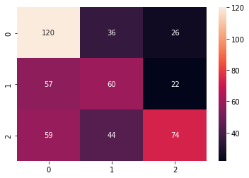

```python
conf_matrix = confusion_matrix(df_sentiments_1["true_polarity"], df_sentiments_1["our_polarity_1"], labels=['positif', 'neutre', 'negatif'])

sns.heatmap(conf_matrix, annot=True, fmt='d')
```

#### Vous donnerez aussi le nombre de termes négatifs contenus dans les tweets positifs.

```python
idx_tweet_positif = df_sentiments_1.index[df_sentiments_1['our_polarity_1'] == "positif"].tolist()

list_tweet_positif_tokenized = list()
neg_word_list = neg_word_df[0].tolist()

for elm in idx_tweet_positif:
    list_tweet_positif_tokenized.append(tweets["tweet_cleaned"][elm])

counter_neg_words = 0

for i in range(len(list_tweet_positif_tokenized)):
    for j in range(len(list_tweet_positif_tokenized[i])):
        if list_tweet_positif_tokenized[i][j].lower() in neg_word_list:
            counter_neg_words = counter_neg_words + 1

print('Approche 1 : Il y a ' + str(counter_neg_words) + ' termes négatifs dans les tweets positifs')
```

```
Approche 1 : Il y a 7 termes négatifs dans les tweets positifs
```

### Approche n°2

Comibinaison des régles **3.4** et **3.5**

```python
def compute_sentiment_score_2(post_tag_tweet):
    accepted_tag = ["NOUN", "ADV", "VERB", "ADJ"]

    dicoSentiWordnetFile = 'data/SentiWordNet_3.0.0_20130122.txt'
    swn_dict = swn.SentiWordNetCorpusReader('', [dicoSentiWordnetFile])

    booster_word_df = pd.read_csv("data/BoosterWordList.txt", sep='\t', header = None)
    booster_word_list = booster_word_df[0].tolist()

    neg_word_df = pd.read_csv("data/NegatingWordList.txt", header = None)
    neg_word_list = neg_word_df[0].tolist()

    list_positive_score = list()
    list_negative_score = list()

    list_positive_score_global = list()
    list_negative_score_global = list()

    # Initialisation : Calcul des score de sentiment du 1er mot du tweet
    senti_dict = list(swn_dict.senti_synsets(post_tag_tweet[0][0]))
    if post_tag_tweet[0][1] in accepted_tag and len(senti_dict) > 0:
        for idx, elm in enumerate(senti_dict):
                word = str(elm).split(".")[0].split("<")[1]
                if word == post_tag_tweet[0][0].lower():
                    list_positive_score.append(senti_dict[idx].pos_score())
                    list_negative_score.append(senti_dict[idx].neg_score())
                    break

    for i in range (1, len(post_tag_tweet)):
        senti_dict = list(swn_dict.senti_synsets(post_tag_tweet[i][0]))
        if post_tag_tweet[i][1] in accepted_tag and len(senti_dict) > 0:
            for idx, elm in enumerate(senti_dict):
                word = str(elm).split(".")[0].split("<")[1]
                if word == post_tag_tweet[i][0].lower():

                    # On vérifie si le mot précédent du mot courant est une négation
                    if post_tag_tweet[i-1][0].lower() in neg_word_list:
                        list_positive_score_global.append(senti_dict[idx].pos_score())
                        list_negative_score_global.append(senti_dict[idx].neg_score())
                        break

                    # Si le mot précédent est un booster on multiplie les scores par 2
                    elif post_tag_tweet[i-1][0].lower() in booster_word_list:
                        list_positive_score.append(senti_dict[idx].pos_score() * 2)
                        list_negative_score.append(senti_dict[idx].neg_score() * 2)
                        break

                    else:
                        list_positive_score.append(senti_dict[idx].pos_score())
                        list_negative_score.append(senti_dict[idx].neg_score())
                        break



    if len(list_positive_score_global) > 0:
        score_positive = list_negative_score_global[0]
        score_negative = list_positive_score_global[0]
    else:
        score_positive = sum(list_positive_score)
        score_negative = sum(list_negative_score)


    # On défnit la classe majoritaire
    if score_positive > score_negative:
        classe = "positif"
    if score_positive < score_negative:
        classe = "negatif"
    if score_positive == score_negative:
        classe = "neutre"

    return [score_positive, score_negative, classe]
```

#### Calcul des scores de sentiment pour chaque tweet

```python
l_sentiment_scores_2 = list()
for i in range(tweets.shape[0]):
    print(i)
    score = compute_sentiment_score_2(tweets.iloc[i,7])
    l_sentiment_scores_2.append(score)

tweets = tweets.join(pd.DataFrame({"sentiment_scores_2":l_sentiment_scores_2}))
tweets
```

[output not shown]

[output cut: 443 more lines]

[output not shown]

|  | polarity | id | date | query | author | content | tweet_cleaned | tweet_pos_tag | sentiment_scores | sentiment_scores_1 | sentiment_scores_2 |
| --- | --- | --- | --- | --- | --- | --- | --- | --- | --- | --- | --- |
| 0 | 4 | 3 | Mon May 11 03:17:40 UTC 2009 | kindle2 | tpryan | @stellargirl I loooooooovvvvvveee my Kindle2. ... | [I, loooooooovvvvvveee, my, Kindle, 2, ., Not,... | [(I, PRON), (loooooooovvvvvveee, VERB), (my, P... | [1.0, 1.0, neutre] | [1.0, 1.0, neutre] | [1.0, 1.0, neutre] |
| 1 | 4 | 4 | Mon May 11 03:18:03 UTC 2009 | kindle2 | vcu451 | Reading my kindle2... Love it... Lee childs i... | [Reading, my, kindle, 2, ..., Love, it, ..., L... | [(Reading, VERB), (my, PRON), (kindle, NOUN), ... | [1.375, 0.0, positif] | [1.375, 0.0, positif] | [1.375, 0.0, positif] |
| 2 | 4 | 5 | Mon May 11 03:18:54 UTC 2009 | kindle2 | chadfu | Ok, first assesment of the #kindle2 ...it fuck... | [Ok, ,, first, assesment, of, the, kindle2, ..... | [(Ok, NOUN), (,, .), (first, ADJ), (assesment,... | [0.125, 0.0, positif] | [0.125, 0.0, positif] | [0.125, 0.0, positif] |
| 3 | 4 | 6 | Mon May 11 03:19:04 UTC 2009 | kindle2 | SIX15 | @kenburbary You'll love your Kindle2. I've had... | [You'll, love, your, Kindle, 2, ., I've, had, ... | [(You'll, NOUN), (love, VERB), (your, PRON), (... | [1.25, 0.875, positif] | [1.25, 1.125, positif] | [1.25, 0.875, positif] |
| 4 | 4 | 7 | Mon May 11 03:21:41 UTC 2009 | kindle2 | yamarama | @mikefish Fair enough. But i have the Kindle2... | [Fair, enough, ., But, i, have, the, Kindle, 2... | [(Fair, NOUN), (enough, ADV), (., .), (But, CO... | [0.25, 0.0, positif] | [0.25, 0.0, positif] | [0.25, 0.0, positif] |
| ... | ... | ... | ... | ... | ... | ... | ... | ... | ... | ... | ... |
| 493 | 2 | 14072 | Sun Jun 14 04:31:43 UTC 2009 | latex | proggit | Ask Programming: LaTeX or InDesign?: submitted... | [Ask, Programming, :, LaTeX, or, InDesign, ?, ... | [(Ask, NOUN), (Programming, NOUN), (:, .), (La... | [0.0, 0.0, neutre] | [0.0, 0.0, neutre] | [0.0, 0.0, neutre] |
| 494 | 0 | 14073 | Sun Jun 14 04:32:17 UTC 2009 | latex | sam33r | On that note, I hate Word. I hate Pages. I hat... | [On, that, note, ,, I, hate, Word, ., I, hate,... | [(On, ADP), (that, DET), (note, NOUN), (,, .),... | [0.5, 1.5, negatif] | [0.5, 1.5, negatif] | [0.5, 1.5, negatif] |
| 495 | 4 | 14074 | Sun Jun 14 04:36:34 UTC 2009 | latex | iamtheonlyjosie | Ahhh... back in a *real* text editing environm... | [Ahhh, ..., back, in, a, *, real, *, text, edi... | [(Ahhh, NOUN), (..., .), (back, ADV), (in, ADP... | [0.0, 0.0, neutre] | [0.0, 0.0, neutre] | [0.0, 0.0, neutre] |
| 496 | 0 | 14075 | Sun Jun 14 21:36:07 UTC 2009 | iran | plutopup7 | Trouble in Iran, I see. Hmm. Iran. Iran so far... | [Trouble, in, Iran, ,, I, see, ., Hmm, ., Iran... | [(Trouble, NOUN), (in, ADP), (Iran, NOUN), (,,... | [0.0, 0.25, negatif] | [0.0, 0.25, negatif] | [0.0, 0.25, negatif] |
| 497 | 0 | 14076 | Sun Jun 14 21:36:17 UTC 2009 | iran | captain_pete | Reading the tweets coming out of Iran... The w... | [Reading, the, tweets, coming, out, of, Iran, ... | [(Reading, VERB), (the, DET), (tweets, NOUN), ... | [0.125, 1.25, negatif] | [0.25, 2.0, negatif] | [0.25, 2.0, negatif] |

498 rows × 11 columns

```python
df_sentiments_2 = pd.DataFrame()

list_our_polarity_classe = list()
list_true_polarity_classe = list()

for i in range(tweets.shape[0]):

    classe = tweets["sentiment_scores_2"][i][2]
    list_our_polarity_classe.append(classe)

    if tweets["polarity"][i] == 4:
        list_true_polarity_classe.append("positif")

    if tweets["polarity"][i] == 2:
        list_true_polarity_classe.append("neutre")

    if tweets["polarity"][i] == 0:
        list_true_polarity_classe.append("negatif")

df_sentiments_2["true_polarity"] = list_true_polarity_classe
df_sentiments_2["our_polarity_2"] = list_our_polarity_classe

df_sentiments_2
```

|  | true_polarity | our_polarity_2 |
| --- | --- | --- |
| 0 | positif | neutre |
| 1 | positif | positif |
| 2 | positif | positif |
| 3 | positif | positif |
| 4 | positif | positif |
| ... | ... | ... |
| 493 | neutre | neutre |
| 494 | negatif | negatif |
| 495 | positif | neutre |
| 496 | negatif | negatif |
| 497 | negatif | negatif |

498 rows × 2 columns

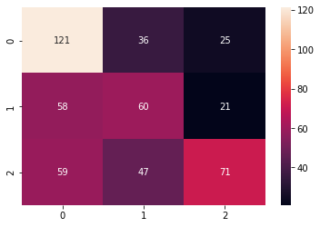

```python
conf_matrix = confusion_matrix(df_sentiments_2["true_polarity"], df_sentiments_2["our_polarity_2"], labels=['positif', 'neutre', 'negatif'])

sns.heatmap(conf_matrix, annot=True, fmt='d')
```

#### Vous donnerez aussi le nombre de termes négatifs contenus dans les tweets positifs.

```python
idx_tweet_positif = df_sentiments_2.index[df_sentiments_2['our_polarity_2'] == "positif"].tolist()

list_tweet_positif_tokenized = list()
neg_word_list = neg_word_df[0].tolist()

for elm in idx_tweet_positif:
    list_tweet_positif_tokenized.append(tweets["tweet_cleaned"][elm])

counter_neg_words = 0

for i in range(len(list_tweet_positif_tokenized)):
    for j in range(len(list_tweet_positif_tokenized[i])):
        if list_tweet_positif_tokenized[i][j].lower() in neg_word_list:
            counter_neg_words = counter_neg_words + 1

print('Approche 2 : Il y a ' + str(counter_neg_words) + ' termes négatifs dans les tweets positifs')
```

```
Approche 2 : Il y a 7 termes négatifs dans les tweets positifs
```

#### Discussion des résultats

On constate globalement que les différentes approches produisent de résultats assez similaire. Cela signifie que les globalement les différentes approches prédisent les mêmes classes de sentiments. L'ajout des nouvelles règles mentionné dans la section 3.5 de l'énoncé apportent un niveau de détail plus fin au niveau des scores des sentiments mais la classe prédites restent globalement toujours la même quelque soit l'approche.

### 6/ Algorithme de détection : gestion des émoticones

Les émoticones positives rencontrées augmentent de 1 la valeur du score positif du tweet, tandis que les émoticones négatives augmentent de 1 la valeur du score négatif du tweet.

L'approche consiste à se contenter uniquement implémenter un algorithme qui calcul les scores de sentiments avec les règles mentionné dans la section 3.6. Cela signifie que l'on se basera uniquement sur les émoticones pour calculer les score de sentiment pour chaque tweet.

#### Lecture de la liste contenant les émoticones

```python
df_emoticon = pd.read_csv("data/EmoticonLookupTable.txt", sep="\t", header=None, names=["emoticone", "score"])
df_emoticon
```

|  | emoticone | score |
| --- | --- | --- |
| 0 | %-( | -1 |
| 1 | %-) | 1 |
| 2 | (-: | 1 |
| 3 | (: | 1 |
| 4 | (^ ^) | 1 |
| ... | ... | ... |
| 110 | xP | -1 |
| 111 | \|8C | -1 |
| 112 | \|8c | -1 |
| 113 | \|D | 1 |
| 114 | }:) | 1 |

115 rows × 2 columns

#### Implémentation de la fonction qui calcul le score en fonction des émoticones

```python
def compute_sentiment_score_3(tweet_cleaned):
    df_emoticon = pd.read_csv("data/EmoticonLookupTable.txt", sep="\t", header=None, names=["emoticone", "score"])
    emoticones_list = df_emoticon['emoticone'].tolist()

    list_positive_score = list()
    list_negative_score = list()

    for elm in tweet_cleaned:
        if elm in emoticones_list:
            score_emoticone = df_emoticon.loc[df_emoticon['emoticone'] == elm]['score'].tolist()[0]
            if score_emoticone == 1:
                list_positive_score.append(1)
            if score_emoticone == -1:
                list_negative_score.append(1)

    score_positive = sum(list_positive_score)
    score_negative = sum(list_negative_score)

    if score_positive > score_negative:
        classe = "positif"
    if score_positive < score_negative:
        classe = "negatif"
    if score_positive == score_negative:
        classe = "neutre"

    return [score_positive, score_negative, classe]
```

#### Calcul des scores de sentiment pour chaque tweet

```python
l_sentiment_scores_3 = list()
for i in range(tweets.shape[0]):
    print(i)
    score = compute_sentiment_score_3(tweets.iloc[i,6])
    l_sentiment_scores_3.append(score)

tweets = tweets.join(pd.DataFrame({"sentiment_scores_3":l_sentiment_scores_3}))
tweets
```

[output not shown]

[output cut: 443 more lines]

[output not shown]

|  | polarity | id | date | query | author | content | tweet_cleaned | tweet_pos_tag | sentiment_scores | sentiment_scores_1 | sentiment_scores_2 | sentiment_scores_3 |
| --- | --- | --- | --- | --- | --- | --- | --- | --- | --- | --- | --- | --- |
| 0 | 4 | 3 | Mon May 11 03:17:40 UTC 2009 | kindle2 | tpryan | @stellargirl I loooooooovvvvvveee my Kindle2. ... | [I, loooooooovvvvvveee, my, Kindle, 2, ., Not,... | [(I, PRON), (loooooooovvvvvveee, VERB), (my, P... | [1.0, 1.0, neutre] | [1.0, 1.0, neutre] | [1.0, 1.0, neutre] | [0, 0, neutre] |
| 1 | 4 | 4 | Mon May 11 03:18:03 UTC 2009 | kindle2 | vcu451 | Reading my kindle2... Love it... Lee childs i... | [Reading, my, kindle, 2, ..., Love, it, ..., L... | [(Reading, VERB), (my, PRON), (kindle, NOUN), ... | [1.375, 0.0, positif] | [1.375, 0.0, positif] | [1.375, 0.0, positif] | [0, 0, neutre] |
| 2 | 4 | 5 | Mon May 11 03:18:54 UTC 2009 | kindle2 | chadfu | Ok, first assesment of the #kindle2 ...it fuck... | [Ok, ,, first, assesment, of, the, kindle2, ..... | [(Ok, NOUN), (,, .), (first, ADJ), (assesment,... | [0.125, 0.0, positif] | [0.125, 0.0, positif] | [0.125, 0.0, positif] | [0, 0, neutre] |
| 3 | 4 | 6 | Mon May 11 03:19:04 UTC 2009 | kindle2 | SIX15 | @kenburbary You'll love your Kindle2. I've had... | [You'll, love, your, Kindle, 2, ., I've, had, ... | [(You'll, NOUN), (love, VERB), (your, PRON), (... | [1.25, 0.875, positif] | [1.25, 1.125, positif] | [1.25, 0.875, positif] | [1, 0, positif] |
| 4 | 4 | 7 | Mon May 11 03:21:41 UTC 2009 | kindle2 | yamarama | @mikefish Fair enough. But i have the Kindle2... | [Fair, enough, ., But, i, have, the, Kindle, 2... | [(Fair, NOUN), (enough, ADV), (., .), (But, CO... | [0.25, 0.0, positif] | [0.25, 0.0, positif] | [0.25, 0.0, positif] | [1, 0, positif] |
| ... | ... | ... | ... | ... | ... | ... | ... | ... | ... | ... | ... | ... |
| 493 | 2 | 14072 | Sun Jun 14 04:31:43 UTC 2009 | latex | proggit | Ask Programming: LaTeX or InDesign?: submitted... | [Ask, Programming, :, LaTeX, or, InDesign, ?, ... | [(Ask, NOUN), (Programming, NOUN), (:, .), (La... | [0.0, 0.0, neutre] | [0.0, 0.0, neutre] | [0.0, 0.0, neutre] | [0, 0, neutre] |
| 494 | 0 | 14073 | Sun Jun 14 04:32:17 UTC 2009 | latex | sam33r | On that note, I hate Word. I hate Pages. I hat... | [On, that, note, ,, I, hate, Word, ., I, hate,... | [(On, ADP), (that, DET), (note, NOUN), (,, .),... | [0.5, 1.5, negatif] | [0.5, 1.5, negatif] | [0.5, 1.5, negatif] | [0, 0, neutre] |
| 495 | 4 | 14074 | Sun Jun 14 04:36:34 UTC 2009 | latex | iamtheonlyjosie | Ahhh... back in a *real* text editing environm... | [Ahhh, ..., back, in, a, *, real, *, text, edi... | [(Ahhh, NOUN), (..., .), (back, ADV), (in, ADP... | [0.0, 0.0, neutre] | [0.0, 0.0, neutre] | [0.0, 0.0, neutre] | [1, 0, positif] |
| 496 | 0 | 14075 | Sun Jun 14 21:36:07 UTC 2009 | iran | plutopup7 | Trouble in Iran, I see. Hmm. Iran. Iran so far... | [Trouble, in, Iran, ,, I, see, ., Hmm, ., Iran... | [(Trouble, NOUN), (in, ADP), (Iran, NOUN), (,,... | [0.0, 0.25, negatif] | [0.0, 0.25, negatif] | [0.0, 0.25, negatif] | [0, 0, neutre] |
| 497 | 0 | 14076 | Sun Jun 14 21:36:17 UTC 2009 | iran | captain_pete | Reading the tweets coming out of Iran... The w... | [Reading, the, tweets, coming, out, of, Iran, ... | [(Reading, VERB), (the, DET), (tweets, NOUN), ... | [0.125, 1.25, negatif] | [0.25, 2.0, negatif] | [0.25, 2.0, negatif] | [0, 0, neutre] |

498 rows × 12 columns

#### Vous préciserez nombre de tweets correctement analysés pour chaque catégorie.

```python
df_sentiments_3 = pd.DataFrame()

list_our_polarity_classe = list()
list_true_polarity_classe = list()

for i in range(tweets.shape[0]):

    classe = tweets["sentiment_scores_3"][i][2]
    list_our_polarity_classe.append(classe)

    if tweets["polarity"][i] == 4:
        list_true_polarity_classe.append("positif")

    if tweets["polarity"][i] == 2:
        list_true_polarity_classe.append("neutre")

    if tweets["polarity"][i] == 0:
        list_true_polarity_classe.append("negatif")

df_sentiments_3["true_polarity"] = list_true_polarity_classe
df_sentiments_3["our_polarity_3"] = list_our_polarity_classe

df_sentiments_3
```

|  | true_polarity | our_polarity_3 |
| --- | --- | --- |
| 0 | positif | neutre |
| 1 | positif | neutre |
| 2 | positif | neutre |
| 3 | positif | positif |
| 4 | positif | positif |
| ... | ... | ... |
| 493 | neutre | neutre |
| 494 | negatif | neutre |
| 495 | positif | positif |
| 496 | negatif | neutre |
| 497 | negatif | neutre |

498 rows × 2 columns

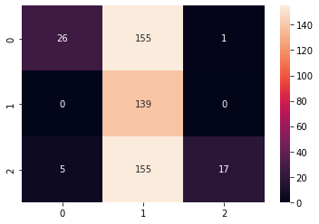

```python
conf_matrix = confusion_matrix(df_sentiments_3["true_polarity"], df_sentiments_3["our_polarity_3"], labels=['positif', 'neutre', 'negatif'])

sns.heatmap(conf_matrix, annot=True, fmt='d')
```

#### Discussion des résultats

On remarque qu'il y a beaucoup de tweets classé dans la classe `neutre`. Ceci s'explique simplement par le fait que peu de tweets contiennent des émoticones donc les scores positifs et négatifs restent fixés à 0

#### Vous donnerez aussi le nombre d’émoticones présents dans le corpus.

```python
df_emoticon = pd.read_csv("data/EmoticonLookupTable.txt", sep="\t", header=None, names=["emoticone", "score"])
emoticones_list = df_emoticon['emoticone'].tolist()

list_tweets_cleaned = tweets["tweet_cleaned"].tolist()

counter_emoticone = 0

for i in range(len(list_tweets_cleaned)):
    for j in range(len(list_tweets_cleaned[i])):
        if list_tweets_cleaned[i][j] in emoticones_list:
            counter_emoticone = counter_emoticone + 1

print('Il y a ' + str(counter_emoticone) + ' émoticones dans le corpus de tweet')
```

```
Il y a 59 émoticones dans le corpus de tweet
```

### Algorithme de détection : votre version vs Vader

Nous avons vu que les règles mentionnées dans la section **3.4** et **3.5** de l'énoncé du TP fournissent globale des résultats presque identique. De plus il s'avère également que la combinaison des règles **3.4** et **3.5** fournissent également des résultats identique en ce qui concerne les classe prédites par les différentes approches. Enfin avec la dernière approche qui se concentre uniquement sur les émoticones pour le calcul des scores de sentiment, on a pu voir que cette approche à tendance a prédire la classe `neutre`. Cela s'explique par le fait beaucoup de tweet de notre corpus ne contiennent pas d'émoticone. Cela signifie donc que le score sentiment positif et négatif d'un tweet reste fixé logiquement à 0 et ainsi la classe `neutre` est prédite.

Pour améliorer et affiner le calcul des scores de sentiment de chaque tweet, l'idée consistera à combiner les règles des sections **3.4**, **3.5** et **3.6**.

```python
def compute_sentiment_score_4(post_tag_tweet):
    accepted_tag = ["NOUN", "ADV", "VERB", "ADJ"]

    dicoSentiWordnetFile = 'data/SentiWordNet_3.0.0_20130122.txt'
    swn_dict = swn.SentiWordNetCorpusReader('', [dicoSentiWordnetFile])

    booster_word_df = pd.read_csv("data/BoosterWordList.txt", sep='\t', header = None)
    booster_word_list = booster_word_df[0].tolist()

    neg_word_df = pd.read_csv("data/NegatingWordList.txt", header = None)
    neg_word_list = neg_word_df[0].tolist()

    df_emoticon = pd.read_csv("data/EmoticonLookupTable.txt", sep="\t", header=None, names=["emoticone", "score"])
    emoticones_list = df_emoticon['emoticone'].tolist()

    list_positive_score = list()
    list_negative_score = list()

    list_positive_score_global = list()
    list_negative_score_global = list()

    # Calcul des scores de sentiment du 1er mot du tweet
    senti_dict = list(swn_dict.senti_synsets(post_tag_tweet[0][0]))
    # On vérifie si le premier est une émoticone
    if post_tag_tweet[0][0] in emoticones_list:
        score_emoticone = df_emoticon.loc[df_emoticon['emoticone'] == post_tag_tweet[i][0]]['score'].tolist()[0]
        if score_emoticone == 1:
            list_positive_score.append(1)
        if score_emoticone == -1:
            list_negative_score.append(1)

    if post_tag_tweet[0][1] in accepted_tag and len(senti_dict) > 0:
        for idx, elm in enumerate(senti_dict):
                word = str(elm).split(".")[0].split("<")[1]
                if word == post_tag_tweet[0][0].lower():
                    list_positive_score.append(senti_dict[idx].pos_score())
                    list_negative_score.append(senti_dict[idx].neg_score())
                    break

    # On parcourt la liste des tags du reste des mot du tweet
    for i in range (1, len(post_tag_tweet)):
        senti_dict = list(swn_dict.senti_synsets(post_tag_tweet[i][0]))

        # On vérifie si le mot courant est une émoticone
        if post_tag_tweet[i][0] in emoticones_list:
            score_emoticone = df_emoticon.loc[df_emoticon['emoticone'] == post_tag_tweet[i][0]]['score'].tolist()[0]
            if score_emoticone == 1:
                list_positive_score.append(1)
                break
            if score_emoticone == -1:
                list_negative_score.append(1)
                break

        if post_tag_tweet[i][1] in accepted_tag and len(senti_dict) > 0:
            for idx, elm in enumerate(senti_dict):
                word = str(elm).split(".")[0].split("<")[1]
                if word == post_tag_tweet[i][0].lower():

                    # On vérifie si le mot précédent du mot courant est un négation
                    if post_tag_tweet[i-1][0].lower() in neg_word_list:
                        list_positive_score_global.append(senti_dict[idx].pos_score())
                        list_negative_score_global.append(senti_dict[idx].neg_score())
                        break

                    # Si le mot précédent est un booster on multiplie les scores par 2
                    elif post_tag_tweet[i-1][0].lower() in booster_word_list:
                        list_positive_score.append(senti_dict[idx].pos_score() * 2)
                        list_negative_score.append(senti_dict[idx].neg_score() * 2)
                        break

                    else:
                        list_positive_score.append(senti_dict[idx].pos_score())
                        list_negative_score.append(senti_dict[idx].neg_score())
                        break



    if len(list_positive_score_global) > 0:
        score_positive = list_negative_score_global[0]
        score_negative = list_positive_score_global[0]
    else:
        score_positive = sum(list_positive_score)
        score_negative = sum(list_negative_score)


    # On défnit la classe majoritaire
    if score_positive > score_negative:
        classe = "positif"
    if score_positive < score_negative:
        classe = "negatif"
    if score_positive == score_negative:
        classe = "neutre"

    return [score_positive, score_negative, classe]
```

#### Calcul des scores de sentiment pour chaque tweet

```python
l_sentiment_scores_4 = list()
for i in range(tweets.shape[0]):
    print(i)
    score = compute_sentiment_score_4(tweets.iloc[i,7])
    l_sentiment_scores_4.append(score)

tweets = tweets.join(pd.DataFrame({"sentiment_scores_4":l_sentiment_scores_4}))
tweets
```

[output not shown]

[output cut: 443 more lines]

[output not shown]

|  | polarity | id | date | query | author | content | tweet_cleaned | tweet_pos_tag | sentiment_scores | sentiment_scores_1 | sentiment_scores_2 | sentiment_scores_3 | sentiment_scores_4 |
| --- | --- | --- | --- | --- | --- | --- | --- | --- | --- | --- | --- | --- | --- |
| 0 | 4 | 3 | Mon May 11 03:17:40 UTC 2009 | kindle2 | tpryan | @stellargirl I loooooooovvvvvveee my Kindle2. ... | [I, loooooooovvvvvveee, my, Kindle, 2, ., Not,... | [(I, PRON), (loooooooovvvvvveee, VERB), (my, P... | [1.0, 1.0, neutre] | [1.0, 1.0, neutre] | [1.0, 1.0, neutre] | [0, 0, neutre] | [1.0, 1.0, neutre] |
| 1 | 4 | 4 | Mon May 11 03:18:03 UTC 2009 | kindle2 | vcu451 | Reading my kindle2... Love it... Lee childs i... | [Reading, my, kindle, 2, ..., Love, it, ..., L... | [(Reading, VERB), (my, PRON), (kindle, NOUN), ... | [1.375, 0.0, positif] | [1.375, 0.0, positif] | [1.375, 0.0, positif] | [0, 0, neutre] | [1.375, 0.0, positif] |
| 2 | 4 | 5 | Mon May 11 03:18:54 UTC 2009 | kindle2 | chadfu | Ok, first assesment of the #kindle2 ...it fuck... | [Ok, ,, first, assesment, of, the, kindle2, ..... | [(Ok, NOUN), (,, .), (first, ADJ), (assesment,... | [0.125, 0.0, positif] | [0.125, 0.0, positif] | [0.125, 0.0, positif] | [0, 0, neutre] | [0.125, 0.0, positif] |
| 3 | 4 | 6 | Mon May 11 03:19:04 UTC 2009 | kindle2 | SIX15 | @kenburbary You'll love your Kindle2. I've had... | [You'll, love, your, Kindle, 2, ., I've, had, ... | [(You'll, NOUN), (love, VERB), (your, PRON), (... | [1.25, 0.875, positif] | [1.25, 1.125, positif] | [1.25, 0.875, positif] | [1, 0, positif] | [2.25, 0.875, positif] |
| 4 | 4 | 7 | Mon May 11 03:21:41 UTC 2009 | kindle2 | yamarama | @mikefish Fair enough. But i have the Kindle2... | [Fair, enough, ., But, i, have, the, Kindle, 2... | [(Fair, NOUN), (enough, ADV), (., .), (But, CO... | [0.25, 0.0, positif] | [0.25, 0.0, positif] | [0.25, 0.0, positif] | [1, 0, positif] | [1.25, 0.0, positif] |
| ... | ... | ... | ... | ... | ... | ... | ... | ... | ... | ... | ... | ... | ... |
| 493 | 2 | 14072 | Sun Jun 14 04:31:43 UTC 2009 | latex | proggit | Ask Programming: LaTeX or InDesign?: submitted... | [Ask, Programming, :, LaTeX, or, InDesign, ?, ... | [(Ask, NOUN), (Programming, NOUN), (:, .), (La... | [0.0, 0.0, neutre] | [0.0, 0.0, neutre] | [0.0, 0.0, neutre] | [0, 0, neutre] | [0.0, 0.0, neutre] |
| 494 | 0 | 14073 | Sun Jun 14 04:32:17 UTC 2009 | latex | sam33r | On that note, I hate Word. I hate Pages. I hat... | [On, that, note, ,, I, hate, Word, ., I, hate,... | [(On, ADP), (that, DET), (note, NOUN), (,, .),... | [0.5, 1.5, negatif] | [0.5, 1.5, negatif] | [0.5, 1.5, negatif] | [0, 0, neutre] | [0.5, 1.5, negatif] |
| 495 | 4 | 14074 | Sun Jun 14 04:36:34 UTC 2009 | latex | iamtheonlyjosie | Ahhh... back in a *real* text editing environm... | [Ahhh, ..., back, in, a, *, real, *, text, edi... | [(Ahhh, NOUN), (..., .), (back, ADV), (in, ADP... | [0.0, 0.0, neutre] | [0.0, 0.0, neutre] | [0.0, 0.0, neutre] | [1, 0, positif] | [1.0, 0.0, positif] |
| 496 | 0 | 14075 | Sun Jun 14 21:36:07 UTC 2009 | iran | plutopup7 | Trouble in Iran, I see. Hmm. Iran. Iran so far... | [Trouble, in, Iran, ,, I, see, ., Hmm, ., Iran... | [(Trouble, NOUN), (in, ADP), (Iran, NOUN), (,,... | [0.0, 0.25, negatif] | [0.0, 0.25, negatif] | [0.0, 0.25, negatif] | [0, 0, neutre] | [0.0, 0.25, negatif] |
| 497 | 0 | 14076 | Sun Jun 14 21:36:17 UTC 2009 | iran | captain_pete | Reading the tweets coming out of Iran... The w... | [Reading, the, tweets, coming, out, of, Iran, ... | [(Reading, VERB), (the, DET), (tweets, NOUN), ... | [0.125, 1.25, negatif] | [0.25, 2.0, negatif] | [0.25, 2.0, negatif] | [0, 0, neutre] | [0.25, 2.0, negatif] |

498 rows × 13 columns

```python
df_sentiments_4 = pd.DataFrame()

list_our_polarity_classe = list()
list_true_polarity_classe = list()

for i in range(tweets.shape[0]):

    classe = tweets["sentiment_scores_4"][i][2]
    list_our_polarity_classe.append(classe)

    if tweets["polarity"][i] == 4:
        list_true_polarity_classe.append("positif")

    if tweets["polarity"][i] == 2:
        list_true_polarity_classe.append("neutre")

    if tweets["polarity"][i] == 0:
        list_true_polarity_classe.append("negatif")

df_sentiments_4["true_polarity"] = list_true_polarity_classe
df_sentiments_4["our_polarity_4"] = list_our_polarity_classe

df_sentiments_4
```

|  | true_polarity | our_polarity_4 |
| --- | --- | --- |
| 0 | positif | neutre |
| 1 | positif | positif |
| 2 | positif | positif |
| 3 | positif | positif |
| 4 | positif | positif |
| ... | ... | ... |
| 493 | neutre | neutre |
| 494 | negatif | negatif |
| 495 | positif | positif |
| 496 | negatif | negatif |
| 497 | negatif | negatif |

498 rows × 2 columns

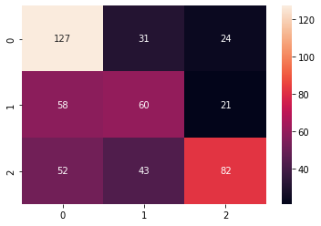

```python
conf_matrix = confusion_matrix(df_sentiments_4["true_polarity"], df_sentiments_4["our_polarity_4"], labels=['positif', 'neutre', 'negatif'])

sns.heatmap(conf_matrix, annot=True, fmt='d')
```

#### Discussion des résultats

On remarque qu'en combinant les différentes approches (association des règles de la section 3.4, 3.5 et 3.6 de l'énoncé), nous obtenons de meilleure performance sur la tâche de classification.

### Utilisation de Vader : Calcul des scores d'un tweet avec l'outil `Vader`

```python
def compute_sentiment_score_vader(tweet):

    sia = SentimentIntensityAnalyzer()
    score = sia.polarity_scores(tweet)
    score_neg = score['neg']
    score_neutre = score['neu']
    score_pos = score['pos']

    score_list = [score_pos, score_neutre, score_neg]

    idx_max_score = score_list.index(max(score_list))

    if idx_max_score == 0:
        classe = "positif"
    if idx_max_score == 1:
        classe = "neutre"
    if idx_max_score == 2:
        classe = "negatif"

    score_global = [score_pos, score_neutre, score_neg, classe]

    return score_global
```

#### Calcul des scores de sentiment pour chaque tweet avec `Vader`

```python
l_sentiment_scores_vader = list()
for i in range(tweets.shape[0]):
    score = compute_sentiment_score_vader(tweets.iloc[i,5])
    l_sentiment_scores_vader.append(score)

tweets = tweets.join(pd.DataFrame({"sentiment_scores_vader":l_sentiment_scores_vader}))
tweets
```

|  | polarity | id | date | query | author | content | tweet_cleaned | tweet_pos_tag | sentiment_scores | sentiment_scores_1 | sentiment_scores_2 | sentiment_scores_3 | sentiment_scores_4 | sentiment_scores_vader |
| --- | --- | --- | --- | --- | --- | --- | --- | --- | --- | --- | --- | --- | --- | --- |
| 0 | 4 | 3 | Mon May 11 03:17:40 UTC 2009 | kindle2 | tpryan | @stellargirl I loooooooovvvvvveee my Kindle2. ... | [I, loooooooovvvvvveee, my, Kindle, 2, ., Not,... | [(I, PRON), (loooooooovvvvvveee, VERB), (my, P... | [1.0, 1.0, neutre] | [1.0, 1.0, neutre] | [1.0, 1.0, neutre] | [0, 0, neutre] | [1.0, 1.0, neutre] | [0.373, 0.627, 0.0, neutre] |
| 1 | 4 | 4 | Mon May 11 03:18:03 UTC 2009 | kindle2 | vcu451 | Reading my kindle2... Love it... Lee childs i... | [Reading, my, kindle, 2, ..., Love, it, ..., L... | [(Reading, VERB), (my, PRON), (kindle, NOUN), ... | [1.375, 0.0, positif] | [1.375, 0.0, positif] | [1.375, 0.0, positif] | [0, 0, neutre] | [1.375, 0.0, positif] | [0.47, 0.53, 0.0, neutre] |
| 2 | 4 | 5 | Mon May 11 03:18:54 UTC 2009 | kindle2 | chadfu | Ok, first assesment of the #kindle2 ...it fuck... | [Ok, ,, first, assesment, of, the, kindle2, ..... | [(Ok, NOUN), (,, .), (first, ADJ), (assesment,... | [0.125, 0.0, positif] | [0.125, 0.0, positif] | [0.125, 0.0, positif] | [0, 0, neutre] | [0.125, 0.0, positif] | [0.278, 0.722, 0.0, neutre] |
| 3 | 4 | 6 | Mon May 11 03:19:04 UTC 2009 | kindle2 | SIX15 | @kenburbary You'll love your Kindle2. I've had... | [You'll, love, your, Kindle, 2, ., I've, had, ... | [(You'll, NOUN), (love, VERB), (your, PRON), (... | [1.25, 0.875, positif] | [1.25, 1.125, positif] | [1.25, 0.875, positif] | [1, 0, positif] | [2.25, 0.875, positif] | [0.285, 0.593, 0.122, neutre] |
| 4 | 4 | 7 | Mon May 11 03:21:41 UTC 2009 | kindle2 | yamarama | @mikefish Fair enough. But i have the Kindle2... | [Fair, enough, ., But, i, have, the, Kindle, 2... | [(Fair, NOUN), (enough, ADV), (., .), (But, CO... | [0.25, 0.0, positif] | [0.25, 0.0, positif] | [0.25, 0.0, positif] | [1, 0, positif] | [1.25, 0.0, positif] | [0.5, 0.5, 0.0, positif] |
| ... | ... | ... | ... | ... | ... | ... | ... | ... | ... | ... | ... | ... | ... | ... |
| 493 | 2 | 14072 | Sun Jun 14 04:31:43 UTC 2009 | latex | proggit | Ask Programming: LaTeX or InDesign?: submitted... | [Ask, Programming, :, LaTeX, or, InDesign, ?, ... | [(Ask, NOUN), (Programming, NOUN), (:, .), (La... | [0.0, 0.0, neutre] | [0.0, 0.0, neutre] | [0.0, 0.0, neutre] | [0, 0, neutre] | [0.0, 0.0, neutre] | [0.0, 1.0, 0.0, neutre] |
| 494 | 0 | 14073 | Sun Jun 14 04:32:17 UTC 2009 | latex | sam33r | On that note, I hate Word. I hate Pages. I hat... | [On, that, note, ,, I, hate, Word, ., I, hate,... | [(On, ADP), (that, DET), (note, NOUN), (,, .),... | [0.5, 1.5, negatif] | [0.5, 1.5, negatif] | [0.5, 1.5, negatif] | [0, 0, neutre] | [0.5, 1.5, negatif] | [0.0, 0.466, 0.534, negatif] |
| 495 | 4 | 14074 | Sun Jun 14 04:36:34 UTC 2009 | latex | iamtheonlyjosie | Ahhh... back in a *real* text editing environm... | [Ahhh, ..., back, in, a, *, real, *, text, edi... | [(Ahhh, NOUN), (..., .), (back, ADV), (in, ADP... | [0.0, 0.0, neutre] | [0.0, 0.0, neutre] | [0.0, 0.0, neutre] | [1, 0, positif] | [1.0, 0.0, positif] | [0.0, 1.0, 0.0, neutre] |
| 496 | 0 | 14075 | Sun Jun 14 21:36:07 UTC 2009 | iran | plutopup7 | Trouble in Iran, I see. Hmm. Iran. Iran so far... | [Trouble, in, Iran, ,, I, see, ., Hmm, ., Iran... | [(Trouble, NOUN), (in, ADP), (Iran, NOUN), (,,... | [0.0, 0.25, negatif] | [0.0, 0.25, negatif] | [0.0, 0.25, negatif] | [0, 0, neutre] | [0.0, 0.25, negatif] | [0.0, 0.787, 0.213, neutre] |
| 497 | 0 | 14076 | Sun Jun 14 21:36:17 UTC 2009 | iran | captain_pete | Reading the tweets coming out of Iran... The w... | [Reading, the, tweets, coming, out, of, Iran, ... | [(Reading, VERB), (the, DET), (tweets, NOUN), ... | [0.125, 1.25, negatif] | [0.25, 2.0, negatif] | [0.25, 2.0, negatif] | [0, 0, neutre] | [0.25, 2.0, negatif] | [0.0, 0.791, 0.209, neutre] |

498 rows × 14 columns

### Vader VS Our predictions

```python
df_sentiments_5 = pd.DataFrame()

list_our_polarity_classe = list()
list_vader_polarity_classe = list()

for i in range(tweets.shape[0]):

    our_classe = tweets["sentiment_scores_4"][i][2]
    list_our_polarity_classe.append(our_classe)

    vader_classe = tweets["sentiment_scores_vader"][i][3]
    list_vader_polarity_classe.append(vader_classe)

df_sentiments_5["vader_polarity"] = list_vader_polarity_classe
df_sentiments_5["our_polarity_5"] = list_our_polarity_classe

df_sentiments_5
```

|  | vader_polarity | our_polarity_5 |
| --- | --- | --- |
| 0 | neutre | neutre |
| 1 | neutre | positif |
| 2 | neutre | positif |
| 3 | neutre | positif |
| 4 | positif | positif |
| ... | ... | ... |
| 493 | neutre | neutre |
| 494 | negatif | negatif |
| 495 | neutre | positif |
| 496 | neutre | negatif |
| 497 | neutre | negatif |

498 rows × 2 columns

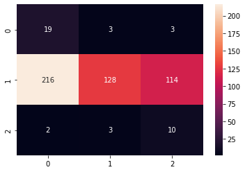

```python
conf_matrix = confusion_matrix(df_sentiments_5["vader_polarity"], df_sentiments_5["our_polarity_5"], labels=['positif', 'neutre', 'negatif'])

sns.heatmap(conf_matrix, annot=True, fmt='d')
```

### Vader VS The truth

```python
df_sentiments_6 = pd.DataFrame()

list_vader_polarity_classe = list()
list_true_polarity_classe = list()

for i in range(tweets.shape[0]):

    vader_classe = tweets["sentiment_scores_vader"][i][3]
    list_vader_polarity_classe.append(vader_classe)

    if tweets["polarity"][i] == 4:
        list_true_polarity_classe.append("positif")

    if tweets["polarity"][i] == 2:
        list_true_polarity_classe.append("neutre")

    if tweets["polarity"][i] == 0:
        list_true_polarity_classe.append("negatif")

df_sentiments_6["true_polarity"] = list_true_polarity_classe
df_sentiments_6["vader_polarity"] = list_vader_polarity_classe

df_sentiments_6
```

|  | true_polarity | vader_polarity |
| --- | --- | --- |
| 0 | positif | neutre |
| 1 | positif | neutre |
| 2 | positif | neutre |
| 3 | positif | neutre |
| 4 | positif | positif |
| ... | ... | ... |
| 493 | neutre | neutre |
| 494 | negatif | negatif |
| 495 | positif | neutre |
| 496 | negatif | neutre |
| 497 | negatif | neutre |

498 rows × 2 columns

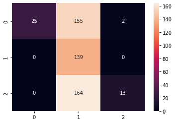

```python
conf_matrix = confusion_matrix(df_sentiments_6["true_polarity"], df_sentiments_6["vader_polarity"], labels=['positif', 'neutre', 'negatif'])

sns.heatmap(conf_matrix, annot=True, fmt='d')
```

#### Discussion des résultats

On remarque que `Vader` ne semble pas fournir des prédictions de qualité car la matrice de confusion montre que `Vader` à tendance à attribuer la classe `neutre` à beaucoup de tweet. En revanche on remarque que notre algorithme d'analyse des sentiments semble être bien plus performant que l'outil `Vader` sur ce jeu de données. On peut donc en déduire que l'outil `Vader` ne se semble pas être approprié pour analyser des textes qui sont au format de tweets autrement dit des textes qui se présentent sous la forme de conversations écrites entre plusieurs utilisateurs du réseau social twitter.

### Visualisons tous les résultats contenu dans le dataframe

```python
pd.set_option('display.max_rows', 500)

tweets
```

|  | polarity | id | date | query | author | content | tweet_cleaned | tweet_pos_tag | sentiment_scores | sentiment_scores_1 | sentiment_scores_2 | sentiment_scores_3 | sentiment_scores_4 | sentiment_scores_vader |
| --- | --- | --- | --- | --- | --- | --- | --- | --- | --- | --- | --- | --- | --- | --- |
| 0 | 4 | 3 | Mon May 11 03:17:40 UTC 2009 | kindle2 | tpryan | @stellargirl I loooooooovvvvvveee my Kindle2. ... | [I, loooooooovvvvvveee, my, Kindle, 2, ., Not,... | [(I, PRON), (loooooooovvvvvveee, VERB), (my, P... | [1.0, 1.0, neutre] | [1.0, 1.0, neutre] | [1.0, 1.0, neutre] | [0, 0, neutre] | [1.0, 1.0, neutre] | [0.373, 0.627, 0.0, neutre] |
| 1 | 4 | 4 | Mon May 11 03:18:03 UTC 2009 | kindle2 | vcu451 | Reading my kindle2... Love it... Lee childs i... | [Reading, my, kindle, 2, ..., Love, it, ..., L... | [(Reading, VERB), (my, PRON), (kindle, NOUN), ... | [1.375, 0.0, positif] | [1.375, 0.0, positif] | [1.375, 0.0, positif] | [0, 0, neutre] | [1.375, 0.0, positif] | [0.47, 0.53, 0.0, neutre] |
| 2 | 4 | 5 | Mon May 11 03:18:54 UTC 2009 | kindle2 | chadfu | Ok, first assesment of the #kindle2 ...it fuck... | [Ok, ,, first, assesment, of, the, kindle2, ..... | [(Ok, NOUN), (,, .), (first, ADJ), (assesment,... | [0.125, 0.0, positif] | [0.125, 0.0, positif] | [0.125, 0.0, positif] | [0, 0, neutre] | [0.125, 0.0, positif] | [0.278, 0.722, 0.0, neutre] |
| 3 | 4 | 6 | Mon May 11 03:19:04 UTC 2009 | kindle2 | SIX15 | @kenburbary You'll love your Kindle2. I've had... | [You'll, love, your, Kindle, 2, ., I've, had, ... | [(You'll, NOUN), (love, VERB), (your, PRON), (... | [1.25, 0.875, positif] | [1.25, 1.125, positif] | [1.25, 0.875, positif] | [1, 0, positif] | [2.25, 0.875, positif] | [0.285, 0.593, 0.122, neutre] |
| 4 | 4 | 7 | Mon May 11 03:21:41 UTC 2009 | kindle2 | yamarama | @mikefish Fair enough. But i have the Kindle2... | [Fair, enough, ., But, i, have, the, Kindle, 2... | [(Fair, NOUN), (enough, ADV), (., .), (But, CO... | [0.25, 0.0, positif] | [0.25, 0.0, positif] | [0.25, 0.0, positif] | [1, 0, positif] | [1.25, 0.0, positif] | [0.5, 0.5, 0.0, positif] |
| 5 | 4 | 8 | Mon May 11 03:22:00 UTC 2009 | kindle2 | GeorgeVHulme | @richardebaker no. it is too big. I'm quite ha... | [no, ., it, is, too, big, ., I'm, quite, happy... | [(no, DET), (., .), (it, PRON), (is, VERB), (t... | [1.0, 0.625, positif] | [1.0, 0.875, positif] | [1.0, 0.625, positif] | [0, 0, neutre] | [1.0, 0.625, positif] | [0.247, 0.618, 0.136, neutre] |
| 6 | 0 | 9 | Mon May 11 03:22:30 UTC 2009 | aig | Seth937 | Fuck this economy. I hate aig and their non lo... | [Fuck, this, economy, ., I, hate, aig, and, th... | [(Fuck, NOUN), (this, DET), (economy, NOUN), (... | [0.125, 0.5, negatif] | [0.125, 0.5, negatif] | [0.125, 0.5, negatif] | [0, 0, neutre] | [0.125, 0.5, negatif] | [0.0, 0.556, 0.444, neutre] |
| 7 | 4 | 10 | Mon May 11 03:26:10 UTC 2009 | jquery | dcostalis | Jquery is my new best friend. | [Jquery, is, my, new, best, friend, .] | [(Jquery, NOUN), (is, VERB), (my, PRON), (new,... | [0.75, 0.0, positif] | [0.75, 0.0, positif] | [0.75, 0.0, positif] | [0, 0, neutre] | [0.75, 0.0, positif] | [0.649, 0.351, 0.0, positif] |
| 8 | 4 | 11 | Mon May 11 03:27:15 UTC 2009 | twitter | PJ_King | Loves twitter | [Loves, twitter] | [(Loves, NOUN), (twitter, NOUN)] | [0, 0, neutre] | [0, 0, neutre] | [0, 0, neutre] | [0, 0, neutre] | [0, 0, neutre] | [0.787, 0.213, 0.0, positif] |
| 9 | 4 | 12 | Mon May 11 03:29:20 UTC 2009 | obama | mandanicole | how can you not love Obama? he makes jokes abo... | [how, can, you, not, love, Obama, ?, he, makes... | [(how, ADV), (can, VERB), (you, PRON), (not, A... | [0.625, 0.625, neutre] | [0.0, 0.625, negatif] | [0.0, 0.625, negatif] | [0, 0, neutre] | [0.0, 0.625, negatif] | [0.139, 0.626, 0.234, neutre] |
| 10 | 2 | 13 | Mon May 11 03:32:42 UTC 2009 | obama | jpeb | Check this video out -- President Obama at the... | [Check, this, video, out, -, -, President, Oba... | [(Check, VERB), (this, DET), (video, NOUN), (o... | [0.0, 0.0, neutre] | [0.0, 0.0, neutre] | [0.0, 0.0, neutre] | [0, 0, neutre] | [0.0, 0.0, neutre] | [0.0, 1.0, 0.0, neutre] |
| 11 | 0 | 14 | Mon May 11 03:32:48 UTC 2009 | obama | kylesellers | @Karoli I firmly believe that Obama/Pelosi hav... | [I, firmly, believe, that, Obama, /, Pelosi, h... | [(I, PRON), (firmly, ADV), (believe, VERB), (t... | [0.875, 0.375, positif] | [0.875, 0.375, positif] | [0.875, 0.375, positif] | [0, 0, neutre] | [0.875, 0.375, positif] | [0.127, 0.691, 0.182, neutre] |
| 12 | 4 | 15 | Mon May 11 03:33:38 UTC 2009 | obama | theviewfans | House Correspondents dinner was last night who... | [House, Correspondents, dinner, was, last, nig... | [(House, NOUN), (Correspondents, NOUN), (dinne... | [0.5, 0.25, positif] | [0.5, 0.25, positif] | [0.5, 0.25, positif] | [0, 0, neutre] | [0.5, 0.25, positif] | [0.0, 1.0, 0.0, neutre] |
| 13 | 4 | 16 | Mon May 11 05:05:58 UTC 2009 | nike | MumsFP | Watchin Espn..Jus seen this new Nike Commerica... | [Watchin, Espn, .., Jus, seen, this, new, Nike... | [(Watchin, NOUN), (Espn, NOUN), (.., NOUN), (J... | [0.75, 0.5, positif] | [0.75, 0.5, positif] | [0.75, 0.5, positif] | [0, 0, neutre] | [0.75, 0.5, positif] | [0.0, 1.0, 0.0, neutre] |
| 14 | 0 | 17 | Mon May 11 05:06:22 UTC 2009 | nike | vincentx24x | dear nike, stop with the flywire. that shit is... | [dear, nike, ,, stop, with, the, flywire, ., t... | [(dear, NOUN), (nike, NOUN), (,, .), (stop, VE... | [1.25, 0.5, positif] | [1.25, 0.5, positif] | [1.25, 0.5, positif] | [0, 0, neutre] | [1.25, 0.5, positif] | [0.237, 0.348, 0.415, negatif] |
| 15 | 4 | 18 | Mon May 11 05:20:15 UTC 2009 | lebron | cameronwylie | #lebron best athlete of our generation, if not... | [lebron, best, athlete, of, our, generation, ,... | [(lebron, NOUN), (best, ADJ), (athlete, NOUN),... | [0.375, 0.75, negatif] | [0.0, 0.0, neutre] | [0.125, 0.125, neutre] | [0, 0, neutre] | [0.125, 0.125, neutre] | [0.172, 0.778, 0.05, neutre] |
| 16 | 0 | 19 | Mon May 11 05:20:28 UTC 2009 | lebron | luv8242 | I was talking to this guy last night and he wa... | [I, was, talking, to, this, guy, last, night, ... | [(I, PRON), (was, VERB), (talking, VERB), (to,... | [0.0, 0.25, negatif] | [0.0, 0.25, negatif] | [0.0, 0.25, negatif] | [0, 0, neutre] | [0.0, 0.25, negatif] | [0.067, 0.696, 0.238, neutre] |
| 17 | 4 | 20 | Mon May 11 05:21:04 UTC 2009 | lebron | mtgillikin | i love lebron. http://bit.ly/PdHur | [i, love, lebron, .] | [(i, NOUN), (love, VERB), (lebron, NOUN), (., .)] | [0.625, 0.0, positif] | [0.625, 0.0, positif] | [0.625, 0.0, positif] | [0, 0, neutre] | [0.625, 0.0, positif] | [0.677, 0.323, 0.0, positif] |
| 18 | 0 | 21 | Mon May 11 05:21:37 UTC 2009 | lebron | ursecretdezire | @ludajuice Lebron is a Beast, but I'm still ch... | [Lebron, is, a, Beast, ,, but, I'm, still, che... | [(Lebron, NOUN), (is, VERB), (a, DET), (Beast,... | [0.0, 0.0, neutre] | [0.0, 0.0, neutre] | [0.0, 0.0, neutre] | [0, 0, neutre] | [0.0, 0.0, neutre] | [0.288, 0.712, 0.0, neutre] |
| 19 | 4 | 22 | Mon May 11 05:21:45 UTC 2009 | lebron | Native_01 | @Pmillzz lebron IS THE BOSS | [lebron, IS, THE, BOSS] | [(lebron, NOUN), (IS, VERB), (THE, DET), (BOSS... | [0.0, 0.0, neutre] | [0.0, 0.0, neutre] | [0.0, 0.0, neutre] | [0, 0, neutre] | [0.0, 0.0, neutre] | [0.0, 1.0, 0.0, neutre] |
| 20 | 4 | 23 | Mon May 11 05:22:03 UTC 2009 | lebron | princezzcutz | @sketchbug Lebron is a hometown hero to me, lo... | [Lebron, is, a, hometown, hero, to, me, ,, lau... | [(Lebron, NOUN), (is, VERB), (a, DET), (hometo... | [1.875, 0.375, positif] | [1.875, 0.375, positif] | [1.875, 0.375, positif] | [0, 0, neutre] | [1.875, 0.375, positif] | [0.467, 0.533, 0.0, neutre] |
| 21 | 4 | 24 | Mon May 11 05:22:12 UTC 2009 | lebron | peterlikewhat | lebron and zydrunas are such an awesome duo | [lebron, and, zydrunas, are, such, an, awesome... | [(lebron, NOUN), (and, CONJ), (zydrunas, NOUN)... | [0.0, 0.125, negatif] | [0.0, 0.125, negatif] | [0.0, 0.125, negatif] | [0, 0, neutre] | [0.0, 0.125, negatif] | [0.369, 0.631, 0.0, neutre] |
| 22 | 4 | 25 | Mon May 11 05:22:37 UTC 2009 | lebron | emceet | @wordwhizkid Lebron is a beast... nobody in th... | [Lebron, is, a, beast, ..., nobody, in, the, N... | [(Lebron, NOUN), (is, VERB), (a, DET), (beast,... | [0.0, 0.0, neutre] | [0.0, 0.0, neutre] | [0.0, 0.0, neutre] | [0, 0, neutre] | [0.0, 0.0, neutre] | [0.0, 1.0, 0.0, neutre] |
| 23 | 4 | 26 | Mon May 11 06:02:24 UTC 2009 | iphone app | CocoSavanna | downloading apps for my iphone! So much fun :-... | [downloading, apps, for, my, iphone, !, So, mu... | [(downloading, VERB), (apps, NOUN), (for, ADP)... | [1.125, 0.125, positif] | [1.25, 0.25, positif] | [1.25, 0.25, positif] | [0, 0, neutre] | [1.25, 0.25, positif] | [0.287, 0.713, 0.0, neutre] |
| 24 | 4 | 33 | Mon May 11 19:47:29 UTC 2009 | visa | DreambigRadio | good news, just had a call from the Visa offic... | [good, news, ,, just, had, a, call, from, the,... | [(good, ADJ), (news, NOUN), (,, .), (just, ADV... | [1.25, 0.125, positif] | [1.25, 0.125, positif] | [1.25, 0.125, positif] | [0, 0, neutre] | [1.25, 0.125, positif] | [0.178, 0.475, 0.347, neutre] |
| 25 | 4 | 34 | Mon May 11 19:49:21 UTC 2009 | fredwilson | andrewwatson | http://twurl.nl/epkr4b - awesome come back fro... | [-, awesome, come, back, from, (, via, )] | [(-, .), (awesome, NOUN), (come, VERB), (back,... | [0.0, 0.0, neutre] | [0.0, 0.0, neutre] | [0.0, 0.0, neutre] | [0, 0, neutre] | [0.0, 0.0, neutre] | [0.369, 0.631, 0.0, neutre] |
| 26 | 4 | 35 | Mon May 11 19:50:07 UTC 2009 | fredwilson | fredwilson | In montreal for a long weekend of R&amp;R. Muc... | [In, montreal, for, a, long, weekend, of, R, &... | [(In, ADP), (montreal, NOUN), (for, ADP), (a, ... | [0.25, 0.125, positif] | [0.25, 0.125, positif] | [0.25, 0.125, positif] | [0, 0, neutre] | [0.25, 0.125, positif] | [0.0, 1.0, 0.0, neutre] |
| 27 | 4 | 46 | Thu May 14 02:58:07 UTC 2009 | "booz allen" | JoeSchueller | Booz Allen Hamilton has a bad ass homegrown so... | [Booz, Allen, Hamilton, has, a, bad, ass, home... | [(Booz, NOUN), (Allen, NOUN), (Hamilton, NOUN)... | [0.5, 1.5, negatif] | [0.5, 1.5, negatif] | [0.5, 1.5, negatif] | [0, 0, neutre] | [0.5, 1.5, negatif] | [0.432, 0.568, 0.0, neutre] |
| 28 | 4 | 47 | Thu May 14 02:58:23 UTC 2009 | "booz allen" | scottabel | [#MLUC09] Customer Innovation Award Winner: Bo... | [[, MLUC09, ], Customer, Innovation, Award, Wi... | [([, ADJ), (MLUC09, NOUN), (], NOUN), (Custome... | [0.0, 0.0, neutre] | [0.0, 0.0, neutre] | [0.0, 0.0, neutre] | [0, 0, neutre] | [0.0, 0.0, neutre] | [0.586, 0.414, 0.0, positif] |
| 29 | 4 | 49 | Thu May 14 05:24:50 UTC 2009 | 40d | JustMe_D | @SoChi2 I current use the Nikon D90 and love i... | [I, current, use, the, Nikon, D90, and, love, ... | [(I, PRON), (current, ADJ), (use, ADP), (the, ... | [0.75, 1.375, negatif] | [0.75, 1.375, negatif] | [0.75, 1.375, negatif] | [0, 0, neutre] | [0.75, 1.375, negatif] | [0.088, 0.808, 0.104, neutre] |

[output cut: 468 more lines]